# Impact des mammites sur la reproduction

Joanna

```r
library(tidyverse)
library(lme4)
library(marginaleffects)
library(readxl)
library(ggplot2)
library(corrplot)
library(questionr)
library(car)
library(ggeffects)
library(GGally)
library(effects)
library(ggpubr)
library(RColorBrewer)
#library(gtsummary)
```

```r
## nombre de jours en dessous duquel on considère qu'on est en début de lactation
## en moyenne avant première IA
early_dim_cutoff <- 90
## SCC cut-off
## seuil de cellules au-delà duquel on considère
## qu'il y a mammite clinique
scc_high_cutoff <- 200
```

# Matériel

## Données

Chargement des données de contrôle laitier fournies par IDELE

```r
rec <- read_csv2("generated_datasets/idele_rec_final.csv") |>
  mutate(
    herd_id = as.character(herd_id),
    ctrl_date = as.Date(ctrl_date),
    anim_id = as.character(anim_id),
    parity = as.integer(parity),
    fat = as.integer(fat),
    prot = as.integer(prot),
    scc = as.integer(scc),
    out_cause = as.character(out_cause),
    calv_date = as.Date(calv_date),
    dim = as.integer(dim)
  ) |>
  filter(!is.na(milk) & !is.na(scc))
```

## Création d’un jeu de données lactations

Dans ce jeu de données on a le contrôle laitier par lactation, qui est l’unité statistique qui nous intéresse. A cela on ajoute les données de la lactation précédente et celles de la lactation suivante. A patir de ces données on définit si la vache est infectée ou non avant tarissement, infectée ou non en début de la lactation suivante et à partir de ça on peut définir si elle s’est infecté au cours du tarissement, si elle a guérit au tarissement ou si elle est restée infectée malgré le tarissement.

```r
lac <- rec |>
  group_by(anim_id, parity) |>
  summarise(
    herd_id = herd_id[1],
    calv_date = unique(calv_date),
    out_date_last = max(out_date),
    out_cause_last = unique(out_cause[out_date == out_date_last]),
    n_ctrl = length(unique(ctrl_date)),
    n_ctrl_early = length(unique(ctrl_date[dim <= early_dim_cutoff])),
    n_scc_high_early = length(scc[scc > scc_high_cutoff & dim <= early_dim_cutoff]),
    milk_early_max = max(milk[dim <= early_dim_cutoff]),
    dim_first = min(dim),
    scc_first = scc[dim == dim_first],
    dim_last = max(dim),
    milk_last = milk[dim == dim_last],
    scc_last = scc[dim == dim_last]
            ) |>
  ungroup() |>
  group_by(anim_id) |>
  mutate(
    calv_date_prev = lag(calv_date),
    milk_last_prev_lac = lag(milk_last),
    dim_last_prev_lac = lag(dim_last),
    scc_last_prev_lac = lag(scc_last),
    calv_date_nxt = lead(calv_date),
    scc_first_nxt_lac = lead(scc_first),
    infct_end_lac = case_when(
     is.na(scc_last) | is.na(scc_first_nxt_lac) ~ NA,
     !is.na(scc_last) & !is.na(scc_first_nxt_lac) & scc_last < scc_high_cutoff ~ "0",
     !is.na(scc_last) & !is.na(scc_first_nxt_lac) & scc_last >= scc_high_cutoff ~ "1"
      ),
    infct_ctrl1_nxt_lac = case_when(
     is.na(scc_last) | is.na(scc_first_nxt_lac) ~ NA,
     !is.na(scc_last) & !is.na(scc_first_nxt_lac) & scc_first_nxt_lac < scc_high_cutoff ~ "0",
     !is.na(scc_last) & !is.na(scc_first_nxt_lac) & scc_first_nxt_lac >= scc_high_cutoff ~ "1"
      ),
    nxt_cure = case_when(
      infct_end_lac == 0 ~ NA,
      infct_end_lac == 1 & infct_ctrl1_nxt_lac == 1 ~ 0,
      infct_end_lac == 1 & infct_ctrl1_nxt_lac == 0 ~ 1
      ),
    nxt_ninf = case_when(
      infct_end_lac == 1 ~ NA,
      infct_end_lac == 0 & infct_ctrl1_nxt_lac == 0 ~ 0,
      infct_end_lac == 0 & infct_ctrl1_nxt_lac == 1 ~ 1
      )
    ) |>
  ungroup()
```

## Ajout des codes de races

```r
path_to_file <- "data/genea.txt"
genea <- read_csv2(path_to_file) |>
rename(anim_id = ANIM,
code_race = CORABO) |>
select(anim_id, code_race)
```

```
## ℹ Using "','" as decimal and "'.'" as grouping mark. Use `read_delim()` for more control.
```

```r
lac_race <- left_join(
  lac |>
    select(anim_id, parity),
  genea) |>
  group_by(anim_id)|>
  ungroup()
lac_race <- lac_race |>
  mutate(race = case_when(code_race == "66" | code_race == "60" ~ "PH",
                          code_race == "46" | code_race == "40" ~ "Montbeliarde",
                          code_race == "56" | code_race == "50" ~ "Normande",
                          code_race == "39" ~ "croisée",
                          code_race != "66" | code_race != "60" | code_race != "46"| code_race != "40" | code_race != "56" | code_race != "50" | code_race != "39" ~ "other"))
```

```r
lac <- left_join(lac, lac_race)
lac <- lac |>
  mutate(race = relevel(factor(race), ref="PH"))
```

```r
table(lac$race)
```

```
##
##           PH      croisée Montbeliarde     Normande        other
##        70962         5586        89521        35831          735
```

## Données mammites cliniques

On va extraire les dates de mammites cliniques afin de les ajouter aux lactations correspondantes sur le tableau de données “lac”

```r
path_to_file <- "data/mammites.txt"
mamt <- read_csv2(path_to_file) |>
rename(anim_id = ANIM,
cm_date = DAMACL) |>
select(anim_id, cm_date)
```

```
## ℹ Using "','" as decimal and "'.'" as grouping mark. Use `read_delim()` for more control.
```

POur chaque lactation on ajoute les dates de mammites cliniques et on considère que les lactations débutent 30 jours avant vêlage (on prend en considération une phase de préparation au vêlage pouvant modifier la sensibilité individuelle et la réponse des animaux)

```r
lac_cm <- left_join(
  lac |>
    select(anim_id, calv_date, calv_date_nxt) |>
    mutate(
      dim_minus30 = calv_date - 30,
      dim_early = calv_date + early_dim_cutoff),
  mamt) |>
  filter(!is.na(cm_date)) |>
  group_by(anim_id, calv_date) |>
  summarise(
    cm_first = min(cm_date[cm_date >= calv_date & (cm_date < calv_date_nxt | is.na(calv_date_nxt))]),
    cm_last = max(cm_date[cm_date >= calv_date & (cm_date < calv_date_nxt | is.na(calv_date_nxt))]),
    n_cm_early = length(unique(cm_date[cm_date >= dim_minus30 & cm_date < dim_early])),
    n_cm_late = length(unique(cm_date[cm_date >= dim_early & (cm_date < calv_date_nxt | is.na(calv_date_nxt))]))
    ) |>
  ungroup()
```

cm_fisrt et cm_last prennent des valeurs égales à -inf et inf –> je ne sais pas encore pourquoi

le code suivant devrait résoudre ce problème

```r
lac_cm$cm_first[is.infinite(lac_cm$cm_first)] <- NA
lac_cm$cm_last[is.infinite(lac_cm$cm_last)] <- NA
```

fusion avec le jeu de données initial

```r
lac <- left_join(lac, lac_cm) |>
  mutate(
    n_cm_early = ifelse(is.na(n_cm_early), 0, n_cm_early),
    n_cm_late = ifelse(is.na(n_cm_late), 0, n_cm_late)
    )
rm(lac_cm) ## supprime lac_cm de l'espace de travail
```

## Données d”insémination artificielle

```r
path_to_file <- "data/extra_femia_20240415.csv"
ai <- read_csv(path_to_file) |>
  select(anim, DAINAR) |>
  rename(anim_id = anim,
         ai_date = DAINAR) |>
  mutate(ai_date = as.Date(ai_date, "%d/%m/%Y"))
```

### Fusion des données d’insémination artificielle avec données lactation

Les données lactations et inséminations artificielles sont fusionnées. On s’assure que chaque date d’IA survient entre un vêlage et le suivant ou entre un vêlage et une absence de vêlage suivant.

```r
nlac <- left_join(lac |>
                    select(anim_id, calv_date, calv_date_nxt),
                  ai) |>
  filter(ai_date > calv_date & (ai_date < calv_date_nxt | is.na(calv_date_nxt))) |>
  group_by(anim_id, calv_date) |>
  summarise(n_ai = length(unique(ai_date)),
            ai_first = min(ai_date),
            ai_last = max(ai_date)) |>
  ungroup()
lac <- left_join(lac, nlac) |>
  mutate(ai1_dim = as.integer(ai_first - calv_date),
         ai_last_dim = as.integer(ai_last - calv_date))
```

## Agrégation des données par élevage et par an

Les données contrôle laitier et inséminations artificielles sont agrégées à l’échelle élevage-année. L’objectif est de sélectionner les élevages dans lesquels une proportion suffisante des vaches sont inséminées. Ici on compte le nombre de contrôle par élevage, le nombre de vaches contrôlées par élevage et la proporions de primipares contrôlées.

```r
rec_hdyr <- rec |>
  mutate(year = as.integer(format(ctrl_date, "%Y"))) |>
  group_by(herd_id, year) |>
  summarise(n_ctrl = length(unique(ctrl_date)),
            n_cows_rec = length(unique(anim_id)),
            p_primi_rec = round(length(parity[parity == 1]) / length(parity), 3)) |>
  ungroup()
```

Les premières IA de chaque élevage sont comptées

```r
ai_hdyr <- lac |>
  filter(!is.na(n_ai)) |>
  mutate(year = as.integer(format(ai_first, "%Y"))) |>
  group_by(herd_id, year) |>
  summarise(n_cows_ai = length(n_ai[!is.na(n_ai)])) |>
  ungroup()
```

Fusion des 2 jeux de données. Seuls les élevages qui ont à la fois des données contrôle laitier et des données d’IA sont conservés.

```r
hdyr <- inner_join(rec_hdyr, ai_hdyr) |>
  mutate(p_ai = round(n_cows_ai / n_cows_rec, 3))
```

On va commencer par ajouter une variable d’année au tableau des lactations. Par année et par élevage on va calculer : - le nombre de vêlages - le nombre de vêlages de primipares - la proportion de vêlages de primipares sur le nombre de vêlage total - le nombre de premières inséminations - la proportion de premières inséminations sur le nombre de vêlages total

```r
lac <- lac |>
  mutate(year = as.integer(format(calv_date, "%Y")))

lac_hrd_yr <- lac |>
  group_by(herd_id, year) |>
  summarise(
    n_calvings = length(anim_id),
    n_calvings_p1 = length(parity[parity == 1]),
    p_calvings_p1 = round(n_calvings_p1 / n_calvings, 3),
    n_ai1 = length(n_ai[!is.na(n_ai)]),
    p_ai_clv = round(n_ai1 / n_calvings, 3)
  )
hdyr <- left_join(hdyr, lac_hrd_yr)
```

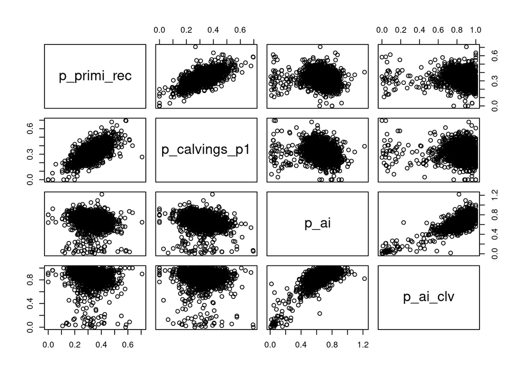

```r
pairs(hdyr[, c("p_primi_rec", "p_calvings_p1", "p_ai", "p_ai_clv")])
```

Le graphique ci-dessous donne en abscisse la proportions de vêlages de primipares et en ordonnées la proportions de premières inséminations par rapport au nombre de vêlages. Cela permet de faire une sélection pour avoir un groupe plus homogène.

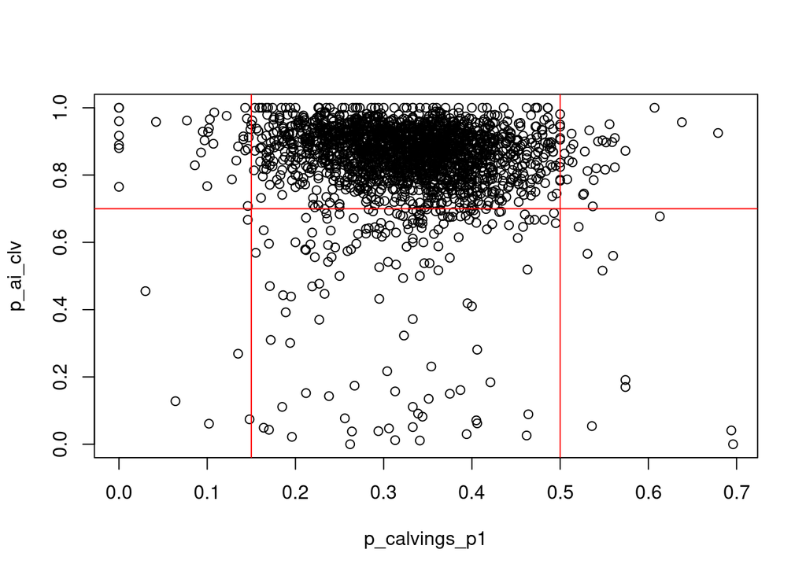

```r
plot(p_ai_clv ~ p_calvings_p1, data = hdyr)
abline(v = c(.15, .5), col = "red")
abline(h = .7, col = "red")
```

```r
hdyr_sel <- hdyr |>
  filter(p_ai_clv > .7 & p_calvings_p1 > .15 & p_calvings_p1 < .5) |>
  select(herd_id, year)

lac <- left_join(hdyr_sel, lac)
```

## Observations conservées pour l’analyse

On ne conserve que les lactations avec au moins 1 contrôle laitier avant 90 jours de lactation.

```r
lac <- lac |>
  filter(n_ctrl_early > 0)
```

## Parités

Pour simplifier l’analyse, je décide de séparer les primipares et les mutlipares. J’utilise la parité 3 comme référence car c’est la parité pour laquelle on considère la vache comme rentable.

```r
lac <- lac |>
  mutate(parKat = relevel(as.factor(ifelse(parity > 3, 4, parity)), ref = "3"))
```

## Production laitière en début de lactation

On va commencer par ajouter la production laitière en début de lactation et la standardiser pour en faire une variable comparable. De plus il faut différencier la PL des primipares avec la PL des multipares car elles ne sont pas vraiment comparables, en réalité une multipare produit généralement plus qu’une primipare.

```r
milk_early_max_mean <- with(lac[lac$n_ctrl_early > 0,],
                            mean(milk_early_max))

milk_early_max_sd   <- with(lac[lac$n_ctrl_early > 0,],
                            sd(milk_early_max))

lac <- lac |>
  filter(n_ctrl_early > 0) |>
  mutate(parKat = relevel(as.factor(ifelse(parity > 3, 4, parity)), ref = "3"),
         milk_early_max_scaled = (milk_early_max - milk_early_max_mean) /
           milk_early_max_sd,
  milk_early_max_scaled_p1 = ifelse(parity == 1, milk_early_max_scaled, 0),
  milk_early_max_scaled_p2 = ifelse(parity == 2, milk_early_max_scaled, 0),
  milk_early_max_scaled_p3 = ifelse(parity == 3, milk_early_max_scaled, 0),
  milk_early_max_scaled_p4 = ifelse(parity > 3, milk_early_max_scaled, 0),
  milk_early_max_scaled_p1plus = ifelse(parity > 1, milk_early_max_scaled, 0))
```

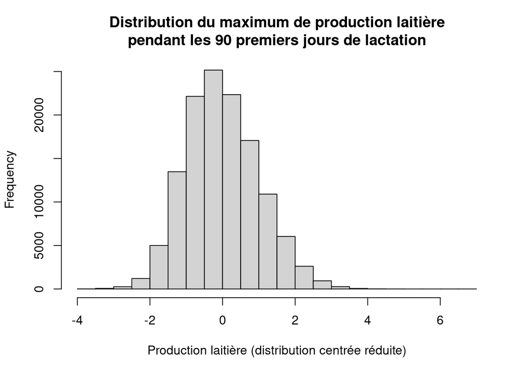

```r
hist(lac$milk_early_max_scaled,
     main = "Distribution du maximum de production laitière\npendant les 90 premiers jours de lactation",
     xlab = "Production laitière (distribution centrée réduite)")
```

## Définition des mammites

Afin de modéliser l’impact des mammites sur la décision de reproduction, il est important de définir les différents types de mammites. On en définit ici : - mammite à réservoir environnementale : typiquement c’est un épisode de mammite isolé qui guérit rapidement et qui ne suit pas un modèle contagieux mais plutôt un modèle sporadique - mammite à réservoir mammaire : mammite qui tend à passer à la chronicité et entraîner une forte contagions au sein de l’élevage.

On va également différencier les différentes périodes de survenue des mammites en se concentrant tout d’abord sur la période de début de lactation : - Les primipares débutent leur toute première lactation, elle n’ont pas encore connu de période sèche et n’ont pas encore eu l’occasion de se contaminer - Les multipares ont déjà pu se contaminer lors de la lactation précédente, on va donc prendre en compte son statut lors de la période sèche.

Le statut “primi” sera donc considéré comme référence.

### Statut au tarissement

```r
lac <- lac |>
  mutate(dp_status = case_when(
    parity == 1 ~ "primi",
    scc_last_prev_lac < scc_high_cutoff ~ "dpLow",
    scc_last_prev_lac >= scc_high_cutoff ~ "dpHigh"),
    dp_status = relevel(factor(dp_status), ref = "primi"))
```

### Type de mammite

```r
lac <- lac |>
  mutate( mast_cat = case_when(
    n_scc_high_early == 0 & n_cm_early == 0 ~ "healthy",
    n_scc_high_early == 1 | (n_scc_high_early == 0 & n_cm_early > 0) ~ "env",
    n_scc_high_early > 1 ~ "cont"),
    mast_cat = relevel(factor( mast_cat), ref = "healthy"),
    mast_cat1 = relevel(factor(paste(dp_status, mast_cat, sep = "_")), ref = "primi_healthy"),
    mast_cat2 = relevel(factor(paste(ifelse(dp_status == "primi", "primi", "multi"), mast_cat, sep = "_")), ref = "primi_healthy")
  )
```

Certaines multipares n’ont pas de données pour la lactation précédente. Elles sont identifiées et exclues de l’analyse.

```r
lac <- lac |>
  mutate(dp_mis = ifelse(parity > 1 & is.na(scc_last_prev_lac), 1, 0))
```

## Probabilité de mise à la reproduction selon le statut de l’animal

```r
## catégories de statuts mammites pour les primipares
mast_lev_p1 <- lac |>
  filter(n_ctrl_early > 0 & dp_mis == 0 & parKat == 1) |>
  distinct(mast_cat1) |>
  mutate(mast_cat1 = as.character(mast_cat1)) |>
  pull(mast_cat1)
## catégories de statuts mammites pour les multipares
mast_lev_p2 <- lac |>
  filter(n_ctrl_early > 0 & dp_mis == 0 & parKat != 1) |>
  distinct(mast_cat1) |>
  mutate(mast_cat1 = as.character(mast_cat1)) |>
  pull(mast_cat1)
```

```r
mast_pred <- tibble(
  parKat = factor(c(rep(1, length(mast_lev_p1)),
                    rep(2, length(mast_lev_p2)))),
  mast_cat1 = factor(c(mast_lev_p1, mast_lev_p2)),
  race = factor(c(rep("PH",length(mast_cat1)))),
  milk_early_max_scaled_p1 = 0,
  milk_early_max_scaled_p2 = 0,
  milk_early_max_scaled_p3 = 0,
  milk_early_max_scaled_p4 = 0,
)

mast_pred1 <- tibble(
  parKat = factor(c(rep(1, length(mast_lev_p1)),
                    rep(2, length(mast_lev_p2)))),
  mast_cat1 = factor(c(mast_lev_p1, mast_lev_p2)),
  race = factor(c(rep("PH",length(mast_cat1)))),
  milk_early_max_scaled_p1 = 0,
  milk_early_max_scaled_p2 = 0,
  milk_early_max_scaled_p3 = 0,
  milk_early_max_scaled_p4 = 0,
  n_ai = 0
)
```

```r
level_order <- c("primi_healthy", "primi_env", "primi_cont",
                 "dpLow_healthy", "dpLow_env", "dpLow_cont",
                 "dpHigh_healthy", "dpHigh_env", "dpHigh_cont")
```

```r
parit_pred <- expand_grid(
  parKat = factor(1:4),
  milk_early_max = 0) |>
  mutate(race = "PH", # Ajustez cette ligne selon les niveaux de la variable 'race'
  milk_early_max_scaled_p1 = 0,
  milk_early_max_scaled_p2 = 0,
  milk_early_max_scaled_p3 = 0,
  milk_early_max_scaled_p4 = 0,
  mast_cat1 = factor(ifelse(parKat == 1, "primi_healthy", "dpLow_healthy"))
)

parit_pred <- parit_pred |>
  mutate(race = as.factor(race))

parit_pred1 <- expand_grid(
  parKat = factor(1:4),
  milk_early_max = 0) |>
  mutate(race = "PH", # Ajustez cette ligne selon les niveaux de la variable 'race'
  milk_early_max_scaled_p1 = 0,
  milk_early_max_scaled_p2 = 0,
  milk_early_max_scaled_p3 = 0,
  milk_early_max_scaled_p4 = 0,
  n_ai = 0,
  mast_cat1 = factor(ifelse(parKat == 1, "primi_healthy", "dpLow_healthy"))
)

parit_pred1 <- parit_pred1 |>
  mutate(race = as.factor(race))
```

```r
milk_pred <- expand_grid(
  parKat = factor(1:4),
  milk_early_max = seq(10, 50, by = .1)
 ) |>
  mutate(
    milk_early_max_scaled = (milk_early_max - milk_early_max_mean) /
           milk_early_max_sd,
    milk_early_max_scaled_p1 = ifelse(parKat == 1, milk_early_max_scaled, 0),
    milk_early_max_scaled_p2 = ifelse(parKat == 2, milk_early_max_scaled, 0),
    milk_early_max_scaled_p3 = ifelse(parKat == 3, milk_early_max_scaled, 0),
    milk_early_max_scaled_p4 = ifelse(parKat == 4, milk_early_max_scaled, 0),
    mast_cat1 = factor(ifelse(parKat == 1, "primi_healthy", "dpLow_healthy")),
    race = "PH"
  )

milk_pred1 <- expand_grid(
  parKat = factor(1:4),
  milk_early_max = seq(10, 50, by = .1)
 ) |>
  mutate(
    milk_early_max_scaled = (milk_early_max - milk_early_max_mean) /
           milk_early_max_sd,
    n_ai = 0,
    milk_early_max_scaled_p1 = ifelse(parKat == 1, milk_early_max_scaled, 0),
    milk_early_max_scaled_p2 = ifelse(parKat == 2, milk_early_max_scaled, 0),
    milk_early_max_scaled_p3 = ifelse(parKat == 3, milk_early_max_scaled, 0),
    milk_early_max_scaled_p4 = ifelse(parKat == 4, milk_early_max_scaled, 0),
    mast_cat1 = factor(ifelse(parKat == 1, "primi_healthy", "dpLow_healthy")),
    race = "PH"
  )
```

```r
nai_pred <- expand_grid(
  parKat = factor(1:4),
  n_ai = seq(1, 10, by = 1)
 ) |>
  mutate(
    milk_early_max_scaled_p1 = 0,
    milk_early_max_scaled_p2 = 0,
    milk_early_max_scaled_p3 = 0,
    milk_early_max_scaled_p4 = 0,
    mast_cat1 = factor(ifelse(parKat == 1, "primi_healthy", "dpLow_healthy")),
    race = "PH")
```

```r
# Définir les catégories de race
race_levels <- c("croisée", "Montbeliarde", "Normande", "other")
```

```r
race_pred <- expand_grid(
  race = factor(c("PH", "Normande", "croisée", "Montbeliarde", "other")),
  milk_early_max = 0) |>
  mutate(parKat = factor(c(rep(3, length(race)))), # Ajustez cette ligne selon les niveaux de la variable 'race'
  milk_early_max_scaled_p1 = 0,
  milk_early_max_scaled_p2 = 0,
  milk_early_max_scaled_p3 = 0,
  milk_early_max_scaled_p4 = 0,
  mast_cat1 = factor(c(rep("dpLow_healthy", length(race)))))

race_pred1 <- expand_grid(
  race = factor(c("PH", "Normande", "croisée", "Montbeliarde", "other")),
  milk_early_max = 0) |>
  mutate(parKat = factor(c(rep(3, length(race)))), # Ajustez cette ligne selon les niveaux de la variable 'race'
  milk_early_max_scaled_p1 = 0,
  milk_early_max_scaled_p2 = 0,
  milk_early_max_scaled_p3 = 0,
  milk_early_max_scaled_p4 = 0,
  n_ai = 0,
  mast_cat1 = factor(c(rep("dpLow_healthy", length(race)))))
```

```r
write_csv2(mast_pred, "generated_datasets/mast_pred.csv")
write_csv2(parit_pred, "generated_datasets/parity_pred.csv")
write_csv2(milk_pred, "generated_datasets/milk_pred.csv")
write_csv2(race_pred, "generated_datasets/race_pred.csv")
```

## Décision de mise à la reproduction

```r
lac <- lac |>
  mutate(
    repro = ifelse(!is.na(n_ai) | !is.na(calv_date_nxt), 1, 0))
```

# Méthode

## Déscription de la mise à la reproduction selon la présence ou non d’une mammite

```r
# Tableau d'effectif
Tab<-table(lac$repro, lac$mast_cat1)
Tab
```

```
##
##     primi_healthy dpHigh_cont dpHigh_env dpHigh_healthy dpLow_cont dpLow_env
##   0          1692        2144       1851           2563        940      1349
##   1         28105        4417       5225          15820       3491      6816
##
##     dpLow_healthy NA_cont NA_env NA_healthy primi_cont primi_env
##   0          3696      42     51        111        441       813
##   1         35640     150    234       1213       3490      7247
```

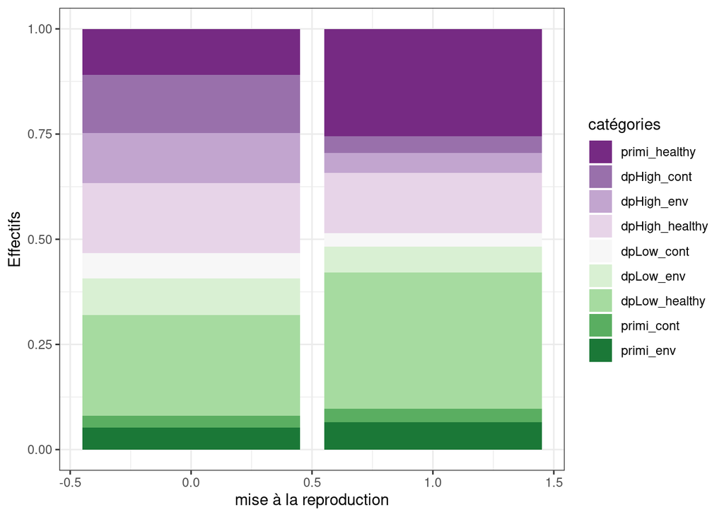

```r
p<-ggplot(lac |>
            filter(n_ctrl_early > 0 & dp_mis == 0)) +
aes(x = repro, fill = mast_cat1) +
geom_bar(position="fill") +
xlab("mise à la reproduction") +
ylab("Effectifs") +
labs(fill = "catégories") +
scale_fill_brewer(palette = "PRGn")
p+theme_bw()
```

```r
## x = Nbre de groupe sur l'axe x
## fill = Nbre de barres par groupe
## position="fill" = rend le graphique proportionnel et empile les barres
```

On va essayer de visualiser les différentes relations entre variables explicatives grâce à une matrice de corrélation.

```r
lac$parKat <- as.numeric(as.factor(lac$parKat))
lac$mast_cat1 <- as.numeric(as.factor(lac$mast_cat1))


# Sélectionner les colonnes d'intérêt
variables_of_interest <- lac[, c("parKat", "milk_early_max_scaled_p1", "milk_early_max_scaled_p2", "milk_early_max_scaled_p3", "milk_early_max_scaled_p4", "mast_cat1", "code_race")]

# Calculer la matrice de corrélation
cor_matrix <- cor(variables_of_interest, use = "complete.obs")
print(cor_matrix)
```

```
##                               parKat milk_early_max_scaled_p1
## parKat                    1.00000000               0.23892442
## milk_early_max_scaled_p1  0.23892442               1.00000000
## milk_early_max_scaled_p2  0.03576703               0.03780232
## milk_early_max_scaled_p3 -0.27988937               0.08266098
## milk_early_max_scaled_p4  0.28263608               0.09081449
## mast_cat1                 0.02595296               0.09754140
## code_race                -0.07575151               0.08145414
##                          milk_early_max_scaled_p2 milk_early_max_scaled_p3
## parKat                                 0.03576703              -0.27988937
## milk_early_max_scaled_p1               0.03780232               0.08266098
## milk_early_max_scaled_p2               1.00000000              -0.01595469
## milk_early_max_scaled_p3              -0.01595469               1.00000000
## milk_early_max_scaled_p4              -0.01752843              -0.03832879
## mast_cat1                              0.03942402               0.04036912
## code_race                              0.14347276               0.11313285
##                          milk_early_max_scaled_p4   mast_cat1   code_race
## parKat                                 0.28263608  0.02595296 -0.07575151
## milk_early_max_scaled_p1               0.09081449  0.09754140  0.08145414
## milk_early_max_scaled_p2              -0.01752843  0.03942402  0.14347276
## milk_early_max_scaled_p3              -0.03832879  0.04036912  0.11313285
## milk_early_max_scaled_p4               1.00000000  0.01505441  0.06841204
## mast_cat1                              0.01505441  1.00000000 -0.01830625
## code_race                              0.06841204 -0.01830625  1.00000000
```

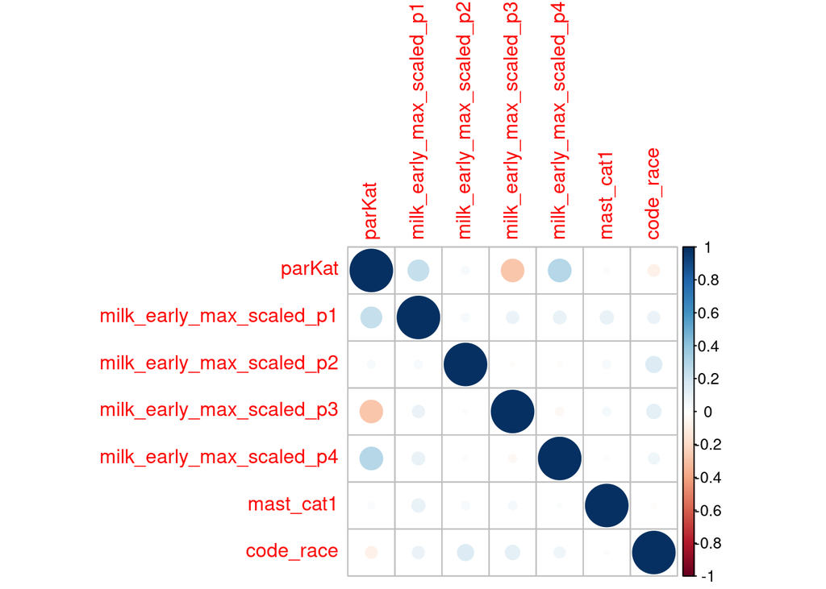

```r
corrplot(cor_matrix, method = "circle")
```

## Modélisation de l’impact des mammites sur la probabilité de mise à la reproduction

```r
lac <- lac |>
  mutate(parKat = relevel(as.factor(ifelse(parity > 3, 4, parity)), ref = "3"),
         mast_cat1 = relevel(factor(paste(dp_status, mast_cat, sep = "_")), ref = "primi_healthy"),
         code_race = relevel(as.factor(code_race), ref = "66"))
```

### Modèle de référence

Ce modèle ne prend que des données parmis des animaux dont on a des informations sur le début de lactation et la période sèche de la précédente lactation.

```r
repro_null <- glmer(repro ~ 1 + (1 | herd_id),
                    data = lac,
                    subset = n_ctrl_early > 0 & dp_mis == 0,
                    family = binomial(link = "logit"))

summary(repro_null)
```

```
## Generalized linear mixed model fit by maximum likelihood (Laplace
##   Approximation) [glmerMod]
##  Family: binomial  ( logit )
## Formula: repro ~ 1 + (1 | herd_id)
##    Data: lac
##  Subset: n_ctrl_early > 0 & dp_mis == 0
##
##      AIC      BIC   logLik deviance df.resid
##  92394.7  92414.2 -46195.3  92390.7   125738
##
## Scaled residuals:
##     Min      1Q  Median      3Q     Max
## -4.6767  0.2902  0.3600  0.4038  0.5573
##
## Random effects:
##  Groups  Name        Variance Std.Dev.
##  herd_id (Intercept) 0.1733   0.4163
## Number of obs: 125740, groups:  herd_id, 231
##
## Fixed effects:
##             Estimate Std. Error z value Pr(>|z|)
## (Intercept)  2.04843    0.03051   67.13   <2e-16 ***
## ---
## Signif. codes:  0 '***' 0.001 '**' 0.01 '*' 0.05 '.' 0.1 ' ' 1
```

```r
# Obtenir les prédictions sur l'échelle de probabilité
predicted_probabilities <- predict(repro_null, type = "response")

# Afficher les premières prédictions pour vérification
head(predicted_probabilities)
```

```
##         1         2         3         4         5         6
## 0.8899503 0.8899503 0.8899503 0.8899503 0.8899503 0.8899503
```

```r
# Définir la fonction invlogit
invlogit <- function(x) {
  exp(x) / (1 + exp(x))
}

# Extraire les coefficients fixes et calculer la probabilité
prob_repro <- as.double(round(invlogit(fixef(repro_null)), 3))

# Afficher la probabilité
prob_repro
```

```
## [1] 0.886
```

### Modèle avec parité et production laitière

```r
repro_parity <- glmer(repro ~ parKat + (1 | herd_id),
                    data = lac,
                    subset = n_ctrl_early > 0 & dp_mis == 0,
                    family = binomial(link = "logit"))

summary(repro_parity)
```

```r
repro_parity_milk <- glmer(repro ~ parKat +
                              milk_early_max_scaled_p1 +
                              milk_early_max_scaled_p2 +
                              milk_early_max_scaled_p3 +
                              milk_early_max_scaled_p4 +
                      (1 | herd_id),
                    data = lac,
                    subset = n_ctrl_early > 0 & dp_mis == 0,
                    family = binomial(link = "logit"))

summary(repro_parity_milk)
```

```r
repro_parity_milk_race <- glmer(repro ~ parKat +
                              milk_early_max_scaled_p1 +
                              milk_early_max_scaled_p2 +
                              milk_early_max_scaled_p3 +
                              milk_early_max_scaled_p4 +
                              code_race +
                      (1 | herd_id),
                    data = lac,
                    subset = n_ctrl_early > 0 & dp_mis == 0,
                    family = binomial(link = "logit"))

summary(repro_parity_milk_race)
```

On va maintenant ajouter la variable d’intêret qui est la présence ou non de mammite

### Modèle complet

```r
repro_full <- glmer(repro ~ parKat +
                              milk_early_max_scaled_p1 +
                              milk_early_max_scaled_p2 +
                              milk_early_max_scaled_p3 +
                              milk_early_max_scaled_p4 +
                             dp_status + mast_cat +
                      (1 | herd_id),
                    data = lac,
                    subset = n_ctrl_early > 0 & dp_mis == 0,
                    family = binomial(link = "logit"))

summary(repro_full)
```

```r
repro_full1 <- glmer(repro ~ parKat +
                              race +
                              milk_early_max_scaled_p1 +
                              milk_early_max_scaled_p2 +
                              milk_early_max_scaled_p3 +
                              milk_early_max_scaled_p4 +
                              mast_cat1 +
                      (1 | herd_id),
                    data = lac,
                    subset = n_ctrl_early > 0 & dp_mis == 0,
                    family = binomial(link = "logit"),
                    control = glmerControl(optimizer = "bobyqa", optCtrl = list(maxfun = 2e5)))
```

```
## fixed-effect model matrix is rank deficient so dropping 1 column / coefficient
```

```r
summary(repro_full1)
```

```
## Generalized linear mixed model fit by maximum likelihood (Laplace
##   Approximation) [glmerMod]
##  Family: binomial  ( logit )
## Formula:
## repro ~ parKat + race + milk_early_max_scaled_p1 + milk_early_max_scaled_p2 +
##     milk_early_max_scaled_p3 + milk_early_max_scaled_p4 + mast_cat1 +
##     (1 | herd_id)
##    Data: lac
## Control: glmerControl(optimizer = "bobyqa", optCtrl = list(maxfun = 2e+05))
##  Subset: n_ctrl_early > 0 & dp_mis == 0
##
##      AIC      BIC   logLik deviance df.resid
##  81251.5  81446.3 -40605.8  81211.5   125482
##
## Scaled residuals:
##     Min      1Q  Median      3Q     Max
## -37.335   0.172   0.267   0.386   2.183
##
## Random effects:
##  Groups  Name        Variance Std.Dev.
##  herd_id (Intercept) 0.4172   0.6459
## Number of obs: 125502, groups:  herd_id, 231
##
## Fixed effects:
##                          Estimate Std. Error z value Pr(>|z|)
## (Intercept)               1.95915    0.06065  32.304  < 2e-16 ***
## parKat1                   2.00323    0.04962  40.374  < 2e-16 ***
## parKat2                   0.54660    0.03007  18.175  < 2e-16 ***
## parKat4                  -0.66943    0.02726 -24.562  < 2e-16 ***
## racecroisée               0.17727    0.05939   2.985  0.00284 **
## raceMontbeliarde          0.56799    0.06355   8.938  < 2e-16 ***
## raceNormande              0.37419    0.04731   7.910 2.58e-15 ***
## raceother                 0.96529    0.20948   4.608 4.06e-06 ***
## milk_early_max_scaled_p1  1.42528    0.03216  44.319  < 2e-16 ***
## milk_early_max_scaled_p2  0.70176    0.02367  29.645  < 2e-16 ***
## milk_early_max_scaled_p3  0.57855    0.02314  25.006  < 2e-16 ***
## milk_early_max_scaled_p4  0.54079    0.01695  31.910  < 2e-16 ***
## mast_cat1dpHigh_cont     -1.31550    0.03443 -38.208  < 2e-16 ***
## mast_cat1dpHigh_env      -1.00106    0.03470 -28.850  < 2e-16 ***
## mast_cat1dpHigh_healthy  -0.29422    0.02905 -10.127  < 2e-16 ***
## mast_cat1dpLow_cont      -0.84229    0.04278 -19.690  < 2e-16 ***
## mast_cat1dpLow_env       -0.56444    0.03615 -15.615  < 2e-16 ***
## mast_cat1primi_cont      -0.70548    0.05954 -11.850  < 2e-16 ***
## mast_cat1primi_env       -0.51940    0.04714 -11.019  < 2e-16 ***
## ---
## Signif. codes:  0 '***' 0.001 '**' 0.01 '*' 0.05 '.' 0.1 ' ' 1
```

```
##
## Correlation matrix not shown by default, as p = 19 > 12.
## Use print(x, correlation=TRUE)  or
##     vcov(x)        if you need it
```

```
## fit warnings:
## fixed-effect model matrix is rank deficient so dropping 1 column / coefficient
```

```r
t_repro <- tbl_regression(repro_full1, exponentiate = TRUE)
print(t_repro)
```

[output not shown]

On va donc maintenant vérifier sa pertinence.

### Vérification du modèle

#### vérification de l’absence de multicolinéarité des variables explicatives

```r
vif(repro_full1)
```

```
##                              GVIF Df GVIF^(1/(2*Df))
## parKat                   5.088775  3        1.311502
## race                     1.063990  4        1.007783
## milk_early_max_scaled_p1 3.315920  1        1.820967
## milk_early_max_scaled_p2 1.054270  1        1.026777
## milk_early_max_scaled_p3 1.120550  1        1.058560
## milk_early_max_scaled_p4 1.153496  1        1.074009
## mast_cat1                2.058140  7        1.052910
```

```r
terms(repro_full1)
```

[output not shown]

## Calcul des effets marginaux

```r
str(mast_pred)
```

```
## tibble [9 × 7] (S3: tbl_df/tbl/data.frame)
##  $ parKat                  : Factor w/ 2 levels "1","2": 1 1 1 2 2 2 2 2 2
##  $ mast_cat1               : Factor w/ 9 levels "dpHigh_cont",..: 9 8 7 1 3 2 6 5 4
##  $ race                    : Factor w/ 1 level "PH": 1 1 1 1 1 1 1 1 1
##  $ milk_early_max_scaled_p1: num [1:9] 0 0 0 0 0 0 0 0 0
##  $ milk_early_max_scaled_p2: num [1:9] 0 0 0 0 0 0 0 0 0
##  $ milk_early_max_scaled_p3: num [1:9] 0 0 0 0 0 0 0 0 0
##  $ milk_early_max_scaled_p4: num [1:9] 0 0 0 0 0 0 0 0 0
```

## Probabilité de mise à la reproduction selon le statut de l’animal

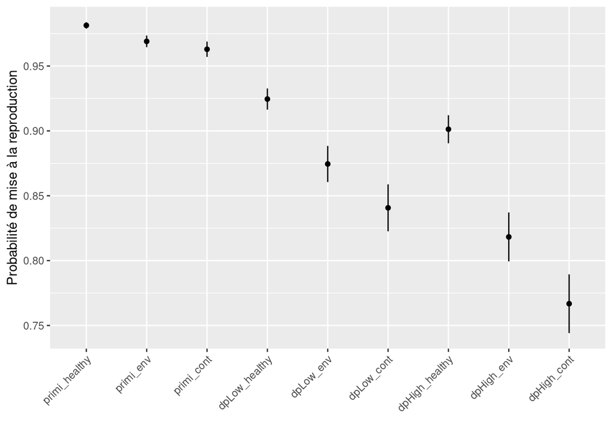

```r
prd <- predictions(model = repro_full1,
                             newdata = mast_pred,
                           re.form = NA, type = "response")

ggplot(prd, aes(x = factor(mast_cat1, level = level_order), y = estimate)) +
  geom_point() +
  geom_segment(aes(x = mast_cat1, y = conf.low, xend = mast_cat1, yend = conf.high)) +
  xlab("") +
  ylab("Probabilité de mise à la reproduction") +
  theme(axis.text.x = element_text(angle = 45, vjust = 1, hjust=1))
```

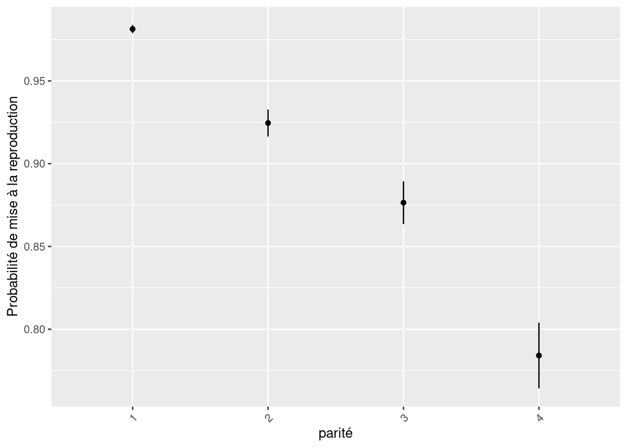

```r
prd <- predictions(model = repro_full1,
                   newdata = parit_pred,
                   re.form = NA, type = "response")

ggplot(prd, aes(x = factor(parKat), y = estimate)) +
  geom_point() +
  geom_segment(aes(x = parKat, y = conf.low, xend = parKat, yend = conf.high)) +
  xlab("parité") +
  ylab("Probabilité de mise à la reproduction") +
  theme(axis.text.x = element_text(angle = 45, vjust = 1, hjust=1))
```

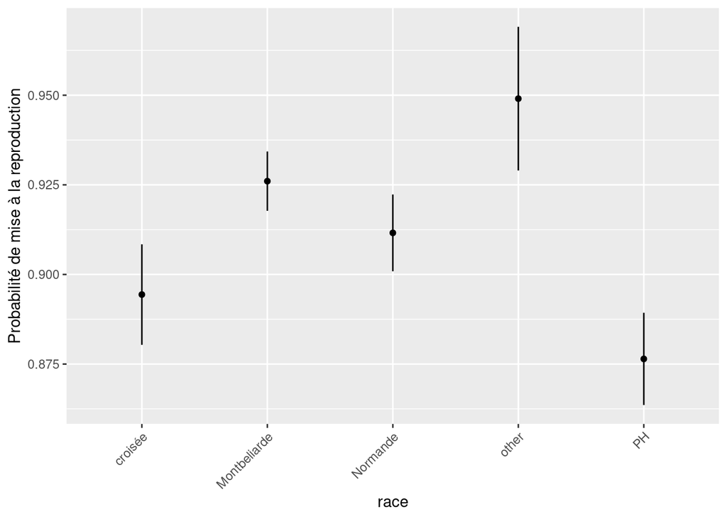

```r
prd <- predictions(model = repro_full1,
                   newdata = race_pred,
                   re.form = NA, type = "response")

ggplot(prd, aes(x = factor(race), y = estimate)) +
  geom_point() +
  geom_segment(aes(x = race, y = conf.low, xend = race, yend = conf.high)) +
  xlab("race") +
  ylab("Probabilité de mise à la reproduction") +
  theme(axis.text.x = element_text(angle = 45, vjust = 1, hjust=1))
```

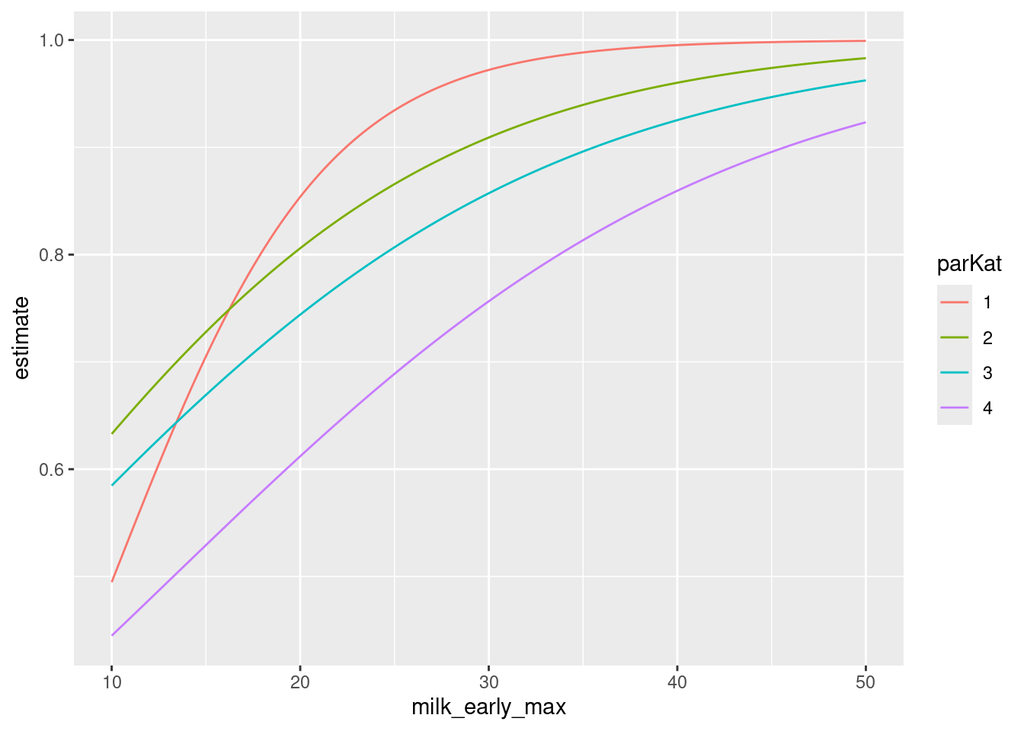

```r
prd <- predictions(model = repro_full1,
                   newdata = milk_pred,
                   re.form = NA, type = "response")

ggplot(prd, aes(x = milk_early_max, y = estimate, col = parKat)) +
  geom_line()
```

## Probabilité de revêlage pour les vaches mises à la reproduction

Une variable binaire prenant la valeur 1 si la vache revêle et 0 autrement est construite.

```r
lac <- lac |>
  mutate(
    repro_revel = case_when(
      repro == 1 & !is.na(calv_date_nxt) ~ 1,
      repro == 1 & is.na(calv_date_nxt) ~ 0,
      repro == 0 ~ NA
    )
    )
```

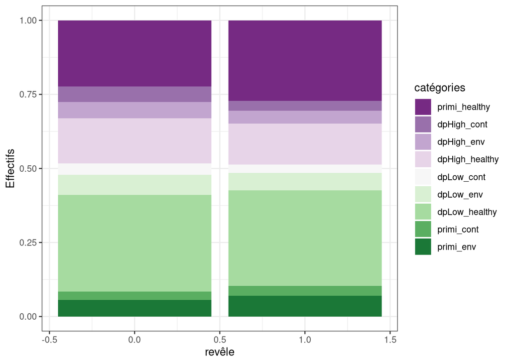

```r
p<-ggplot(lac |>
            filter(n_ctrl_early > 0 & repro == 1 & dp_mis == 0)) +
aes(x = repro_revel, fill = mast_cat1) +
geom_bar(position="fill") +
xlab("revêle") +
ylab("Effectifs") +
labs(fill = "catégories") +
scale_fill_brewer(palette = "PRGn")
p+theme_bw()
```

```r
## x = Nbre de groupe sur l'axe x
## fill = Nbre de barres par groupe
## position="fill" = rend le graphique proportionnel et empile les barres
```

Le modèle suivant estime la probabilité qu’une vache mise à la reproduction revêle.

```r
repro_revel_null <- glmer(repro_revel ~ 1 + (1 |herd_id),
                          family = binomial(link = "logit"),
                          data = lac,
                    subset = n_ctrl_early > 0 & repro == 1 & dp_mis == 0)

summary(repro_revel_null)
```

```
## Generalized linear mixed model fit by maximum likelihood (Laplace
##   Approximation) [glmerMod]
##  Family: binomial  ( logit )
## Formula: repro_revel ~ 1 + (1 | herd_id)
##    Data: lac
##  Subset: n_ctrl_early > 0 & repro == 1 & dp_mis == 0
##
##      AIC      BIC   logLik deviance df.resid
## 136873.8 136893.1 -68434.9 136869.8   110249
##
## Scaled residuals:
##     Min      1Q  Median      3Q     Max
## -2.9104 -1.2031  0.6016  0.7078  3.8621
##
## Random effects:
##  Groups  Name        Variance Std.Dev.
##  herd_id (Intercept) 1.03     1.015
## Number of obs: 110251, groups:  herd_id, 231
##
## Fixed effects:
##             Estimate Std. Error z value Pr(>|z|)
## (Intercept)  0.35090    0.06818   5.147 2.65e-07 ***
## ---
## Signif. codes:  0 '***' 0.001 '**' 0.01 '*' 0.05 '.' 0.1 ' ' 1
```

```r
# Définir la fonction invlogit
invlogit <- function(x) {
  exp(x) / (1 + exp(x))
}

# Extraire les coefficients fixes et calculer la probabilité
prob_revel <- as.double(round(invlogit(fixef(repro_revel_null)), 3))

# Afficher la probabilité
prob_revel
```

```
## [1] 0.587
```

On va maintenant compliquer graduellement le modèle en essayant de trouver le modèle le plus juste possible. On va commencer par utiliser exactement les mêmes variables que pour le modèle de mise à la reproduction.

```r
repro_revel_mast <- glmer(repro_revel ~  parKat +
                              milk_early_max_scaled_p1 +
                              milk_early_max_scaled_p2 +
                              milk_early_max_scaled_p3 +
                              milk_early_max_scaled_p4 +
                              mast_cat1 +
                              race +
                           (1 |herd_id),
                          family = binomial(link = "logit"),
                          data = lac,
                         subset = n_ctrl_early > 0 & repro == 1 & dp_mis == 0)

summary(repro_revel_mast)
```

```r
repro_revel_mast1 <- glmer(repro_revel ~  parKat +
                              milk_early_max_scaled_p1 +
                              milk_early_max_scaled_p2 +
                              milk_early_max_scaled_p3 +
                              milk_early_max_scaled_p4 +
                              mast_cat1 +
                              n_ai +
                           (1 |herd_id),
                          family = binomial(link = "logit"),
                          data = lac,
                         subset = n_ctrl_early > 0 & repro == 1 & dp_mis == 0)
```

```
## fixed-effect model matrix is rank deficient so dropping 1 column / coefficient
```

```r
summary(repro_revel_mast1)
```

```
## Generalized linear mixed model fit by maximum likelihood (Laplace
##   Approximation) [glmerMod]
##  Family: binomial  ( logit )
## Formula:
## repro_revel ~ parKat + milk_early_max_scaled_p1 + milk_early_max_scaled_p2 +
##     milk_early_max_scaled_p3 + milk_early_max_scaled_p4 + mast_cat1 +
##     n_ai + (1 | herd_id)
##    Data: lac
##  Subset: n_ctrl_early > 0 & repro == 1 & dp_mis == 0
##
##      AIC      BIC   logLik deviance df.resid
## 127710.6 127873.8 -63838.3 127676.6   109393
##
## Scaled residuals:
##     Min      1Q  Median      3Q     Max
## -4.5723 -0.9673  0.5066  0.6719 25.7026
##
## Random effects:
##  Groups  Name        Variance Std.Dev.
##  herd_id (Intercept) 0.805    0.8972
## Number of obs: 109410, groups:  herd_id, 231
##
## Fixed effects:
##                           Estimate Std. Error z value Pr(>|z|)
## (Intercept)               1.132957   0.064606  17.536  < 2e-16 ***
## parKat1                   0.550561   0.028553  19.282  < 2e-16 ***
## parKat2                   0.166536   0.023107   7.207 5.71e-13 ***
## parKat4                  -0.309494   0.024454 -12.656  < 2e-16 ***
## milk_early_max_scaled_p1  0.321148   0.019443  16.517  < 2e-16 ***
## milk_early_max_scaled_p2  0.138027   0.016189   8.526  < 2e-16 ***
## milk_early_max_scaled_p3  0.059953   0.018145   3.304 0.000953 ***
## milk_early_max_scaled_p4  0.144737   0.016087   8.997  < 2e-16 ***
## mast_cat1dpHigh_cont     -0.469353   0.034961 -13.425  < 2e-16 ***
## mast_cat1dpHigh_env      -0.235397   0.032912  -7.152 8.54e-13 ***
## mast_cat1dpHigh_healthy  -0.051686   0.021820  -2.369 0.017850 *
## mast_cat1dpLow_cont      -0.388654   0.038359 -10.132  < 2e-16 ***
## mast_cat1dpLow_env       -0.184467   0.029296  -6.297 3.04e-10 ***
## mast_cat1primi_cont      -0.126676   0.041804  -3.030 0.002443 **
## mast_cat1primi_env        0.015218   0.031325   0.486 0.627096
## n_ai                     -0.347391   0.004551 -76.326  < 2e-16 ***
## ---
## Signif. codes:  0 '***' 0.001 '**' 0.01 '*' 0.05 '.' 0.1 ' ' 1
```

```
##
## Correlation matrix not shown by default, as p = 16 > 12.
## Use print(x, correlation=TRUE)  or
##     vcov(x)        if you need it
```

```
## fit warnings:
## fixed-effect model matrix is rank deficient so dropping 1 column / coefficient
```

Le modèle que je retiens est “repro_revel_mast1”, pour l’instant c’est celui qui nous convient le mieux.

### Vérification du modèle

#### vérification de l’absence de multicolinéarité des variables explicatives

```r
vif(repro_revel_mast1)
```

```
##                              GVIF Df GVIF^(1/(2*Df))
## parKat                   4.041235  3        1.262076
## milk_early_max_scaled_p1 1.883806  1        1.372518
## milk_early_max_scaled_p2 1.069933  1        1.034375
## milk_early_max_scaled_p3 1.298993  1        1.139734
## milk_early_max_scaled_p4 1.288575  1        1.135154
## mast_cat1                1.705025  7        1.038848
## n_ai                     1.012631  1        1.006296
```

## Probabilité de revêlage suite à la mise à la reproduction selon la parité

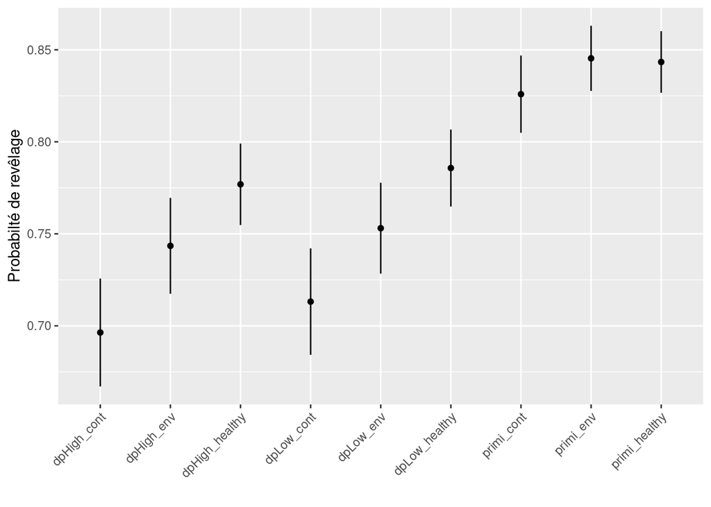

```r
prd <- marginaleffects::predictions(model = repro_revel_mast1,
                             newdata = mast_pred1,
                           re.form = NA, type = "response")

ggplot(prd, aes(x = factor(mast_cat1), y = estimate)) +
  geom_point() +
  geom_segment(aes(x = mast_cat1, y = conf.low, xend = mast_cat1, yend = conf.high)) +
  xlab("") +
  ylab("Probabilté de revêlage") +
  theme(axis.text.x = element_text(angle = 45, vjust = 1, hjust=1))
```

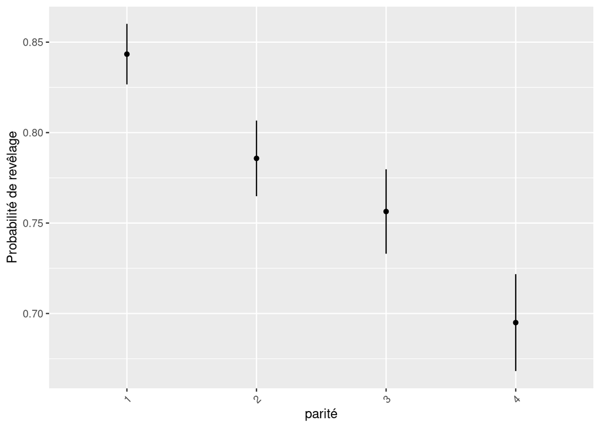

```r
prd <- marginaleffects::predictions(model = repro_revel_mast1,
                             newdata = parit_pred1,
                           re.form = NA, type = "response")

ggplot(prd, aes(x = factor(parKat), y = estimate)) +
  geom_point() +
  geom_segment(aes(x = parKat, y = conf.low, xend = parKat, yend = conf.high)) +
  xlab("parité") +
  ylab("Probabilité de revêlage") +
  theme(axis.text.x = element_text(angle = 45, vjust = 1, hjust=1))
```

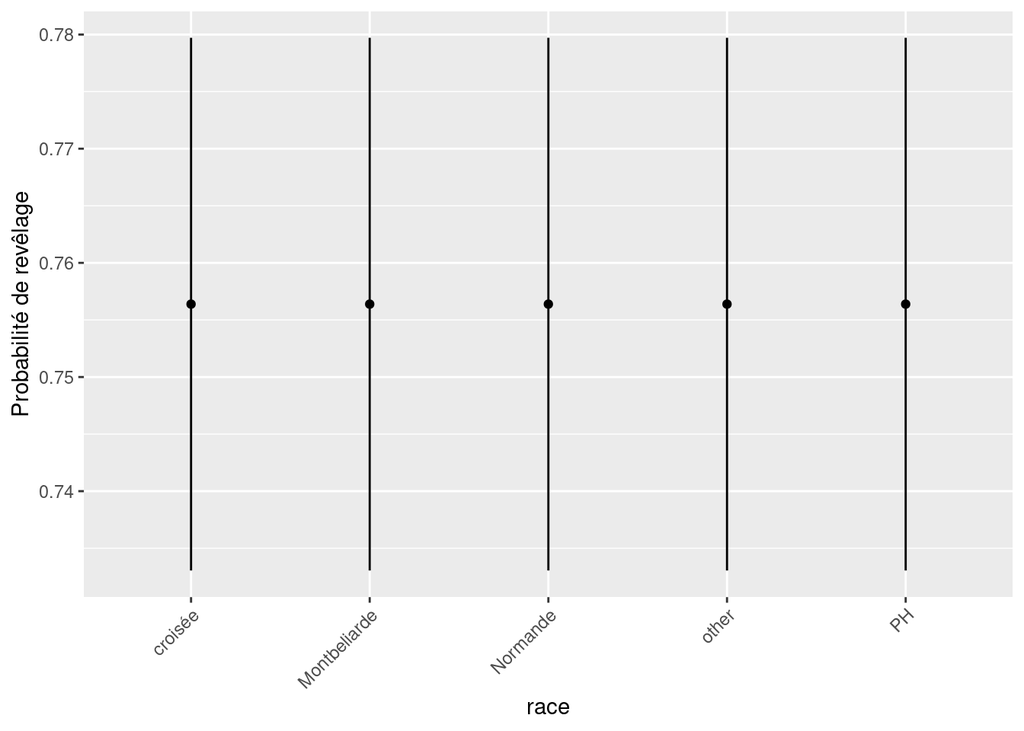

```r
prd <- marginaleffects::predictions(model = repro_revel_mast1,
                             newdata = race_pred1,
                           re.form = NA, type = "response")

ggplot(prd, aes(x = factor(race), y = estimate)) +
  geom_point() +
  geom_segment(aes(x = race, y = conf.low, xend = race, yend = conf.high)) +
  xlab("race") +
  ylab("Probabilité de revêlage") +
  theme(axis.text.x = element_text(angle = 45, vjust = 1, hjust=1))
```

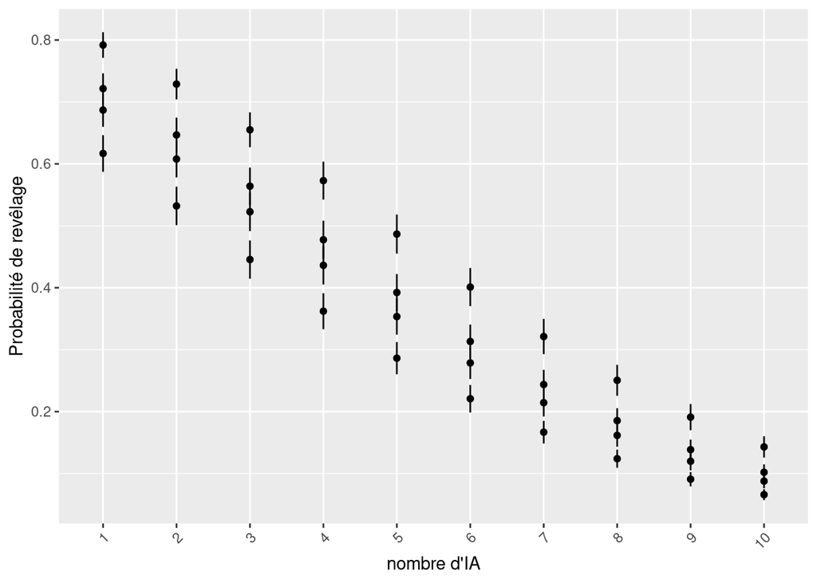

```r
prd <- marginaleffects::predictions(model = repro_revel_mast1,
                             newdata = nai_pred,
                           re.form = NA, type = "response")

ggplot(prd, aes(x = factor(n_ai), y = estimate)) +
  geom_point() +
  geom_segment(aes(x = n_ai, y = conf.low, xend = n_ai, yend = conf.high)) +
  xlab("nombre d'IA") +
  ylab("Probabilité de revêlage") +
  theme(axis.text.x = element_text(angle = 45, vjust = 1, hjust=1))
```

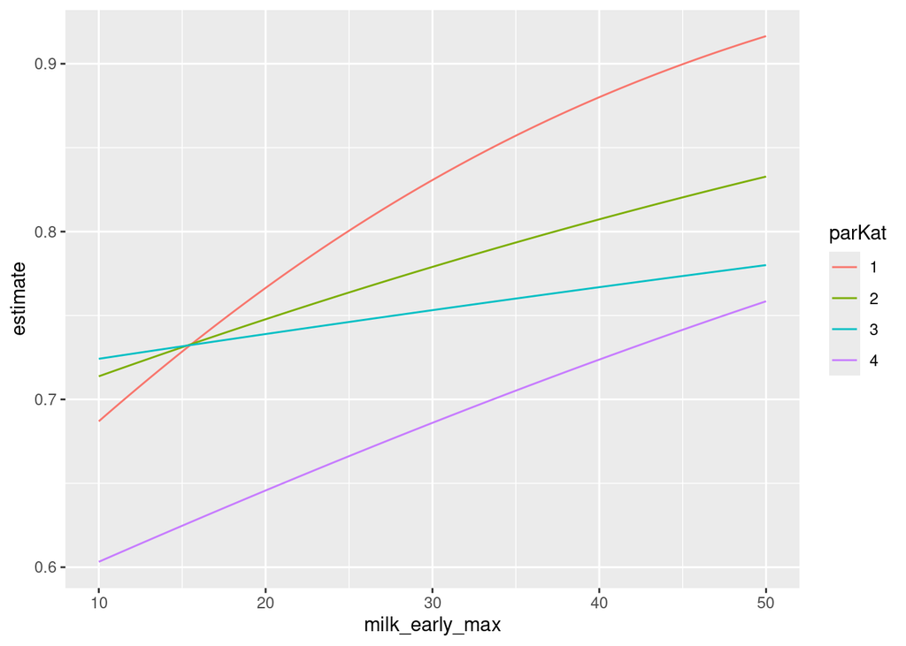

```r
prd <- predictions(model = repro_revel_mast1,
                             newdata = milk_pred1,
                           re.form = NA, type = "response")

ggplot(prd, aes(x = milk_early_max, y = estimate, col = parKat)) +
  geom_line()
```